# Human Genomics

#### Introduction to mathematical operations on matrices

Just like vectors, matrices in R allow for straightforward mathematical operations. Since matrices are essentially two-dimensional arrays of numbers, you can perform various element-wise and matrix-specific operations easily. Let’s first create a matrix using the `matrix()` function.

```r
# Create a 3x3 matrix with numbers 1 to 9
m <- matrix(1:9, nrow = 3, ncol = 3)

# Print the matrix
print(m)
```

```
##      [,1] [,2] [,3]
## [1,]    1    4    7
## [2,]    2    5    8
## [3,]    3    6    9
```

Operations like addition, subtraction, multiplication, and division can be applied **element-wise** in matrices, just as in vectors.

```r
# Element-wise addition
m + 2

# Element-wise subtraction
m - 3

# Element-wise multiplication
m * 2
```

[output not shown]

```r
# Element-wise division
m / 2
```

```
##      [,1] [,2] [,3]
## [1,]  0.5  2.0  3.5
## [2,]  1.0  2.5  4.0
## [3,]  1.5  3.0  4.5
```

If you have a vector, `R` automatically applies operations to each row or column of the matrix.

```r
v <- c(1, 2, 3)

# Add vector to each column
m + v
```

```
##      [,1] [,2] [,3]
## [1,]    2    5    8
## [2,]    4    7   10
## [3,]    6    9   12
```

```r
# Multiply vector with each row
m * v
```

```
##      [,1] [,2] [,3]
## [1,]    1    4    7
## [2,]    4   10   16
## [3,]    9   18   27
```

You can perform addition and subtraction on matrices of the same dimensions.

```r
A <- matrix(1:4, nrow = 2)
B <- matrix(5:8, nrow = 2)

# Matrix addition
A + B
```

```
##      [,1] [,2]
## [1,]    6   10
## [2,]    8   12
```

Linear algebra can be extremely useful for improving the speed on a function. One common operation is matrix multiplication, which is done using the `%*%` operator, not the `*` operator, which performs element-wise multiplication.

```r
A <- matrix(1:4,ncol=2,nrow=2,byrow=T)
print(A)
```

```
##      [,1] [,2]
## [1,]    1    2
## [2,]    3    4
```

```r
A*A
```

```
##      [,1] [,2]
## [1,]    1    4
## [2,]    9   16
```

The true matrix multiplication is defined as:
$$\begin{equation}
\begin{bmatrix}
A_{1,1} & A_{1,2} \\
A_{2,1} & A_{2,2} \\
\end{bmatrix}
\times
\begin{bmatrix}
A_{1,1} & A_{1,2} \\
A_{2,1} & A_{2,2} \\
\end{bmatrix}
=
\begin{bmatrix}
\sum_{j=1}^2 (A_{1,j}\times A_{j,1} ) & \sum_{j=1}^2
(A_{1,j}\times A_{j,2} ) \\
\sum_{j=1}^2 (A_{2,j}\times A_{j,1} ) & \sum_{j=1}^2
(A_{2,j}\times A_{j,2} ) \\
\end{bmatrix}
\end{equation}$$

```r
A%*%A
```

```
##      [,1] [,2]
## [1,]    7   10
## [2,]   15   22
```

The transpose of a matrix (switching rows and columns) is done using the `t()` function.

```r
t(A)
```

```
##      [,1] [,2]
## [1,]    1    3
## [2,]    2    4
```

You can compute the determinant (thus, if `det(A) !=0` the matrix is invertible) and inverse of a square matrix using the `det()` and `solve()` functions, respectively.

```r
# Determinant of matrix A
det(A)
```

```
## [1] -2
```

```r
# Inverse of matrix A
solve(A)
```

```
##      [,1] [,2]
## [1,] -2.0  1.0
## [2,]  1.5 -0.5
```

You can compute row-wise and column-wise summaries easily using functions like `rowSums()` and `colSums()`.

```r
# Sum of each row
rowSums(m)
```

```
## [1] 12 15 18
```

```r
# Sum of each column
colSums(m)
```

```
## [1]  6 15 24
```

Other functions like `rowMeans()` and `colMeans()` calculate averages.

You can apply custom functions to rows or columns using the `apply()` function,

```r
# Calculate maximum value in each row
apply(m, 1, max)
```

```
## [1] 7 8 9
```

```r
# Calculate sum of each column
apply(m, 2, sum)
```

```
## [1]  6 15 24
```

where the second argument specifies the direction (`1` for rows, `2` for columns).

#### Using and writing functions

There exists many pre-defined functions within R, but you can also create your own. For example, you can calculate the mean (average) and standard deviation (SD) of a set of numbers using both built-in functions and custom user-defined functions.

Suppose that we have measured the height for $n=5$ individuals:

```r
y <- c(173, 184, 168, 177,187) # vector of observations
n <- length(y)                 # store how many observations we have
```

The **mean** ($\bar{x}$) height is the sum of the values divided by the number of observations,
$$\bar{x} = \frac{1}{n} \sum_{i=1}^n \textrm{y}_i =
\frac{173 + 184 + 168 + 177 + 187}{5}=177.8$$
We can use the buit-in function `mean()` to compute it:

```r
# Calculate mean
mean_value <- mean(y)
print(mean_value)
```

```
## [1] 177.8
```

We can define our own function for calculating the mean of height:

```r
calculate_mean <- function(x) {
  sum(x) / length(x)
}

# Test the function
calculate_mean(y)
```

```
## [1] 177.8
```

To have an idea how much the values of height *vary* around the mean we can use **standard deviation**, that is, the square root of **variance**. The **variance** is the average squared deviation from the mean. When variance is computed from a sample of size $n$, whose mean is first estimated from that same sample, then the denominator in variance calculation is $n-1$ rather than $n$, so
$$\begin{align}
\textrm{variance} &=
\frac{1}{n-1}\sum_{i=1}^n(\textrm{y}_i-\bar{x})^2 \notag \\
&= \frac{(173-177.8)^2 + (184-177.8)^2 +
(168-177.8)^2 + (177-177.8)^2 + (187-177.8)^2}{4} \notag \\
&= 60.7 \notag \\
\end{align}$$

This can be done as:

```r
sum((y - mean(y))^2) / (n - 1)
```

```
## [1] 60.7
```

or using the built-in `var()`-function.

```r
var(y)
```

```
## [1] 60.7
```

#### Making figures in R

`R` provides powerful tools for creating visualizations to explore and present data effectively. There are several ways to make plots in `R`, ranging from basic built-in plotting functions to advanced graphics packages like **ggplot2**.

##### Basic Plots Using Base R

Base `R` offers simple functions to create quick visualizations. The most commonly used plotting function is `plot()`, which can generate scatter plots, line plots, and more.

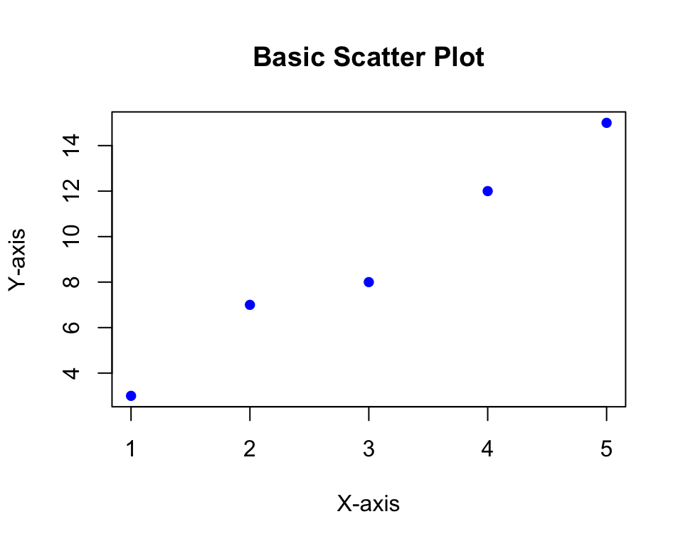

```r
# Sample data
x <- c(1, 2, 3, 4, 5)
y <- c(3, 7, 8, 12, 15)

# Create a scatter plot
plot(x, y,
     main = "Basic Scatter Plot",
     xlab = "X-axis",
     ylab = "Y-axis",
     col = "blue",
     pch = 16)
```

Key Parameters:

- `main` adds a title to the plot.
- `xlab` and `ylab` labels the axes.
- `col` sets color for points.
- `pch` specifies point style (e.g., circles, squares).

Using `type = "l"` creates a line plot instead of points, where the argument `lwd` adjusts line width.

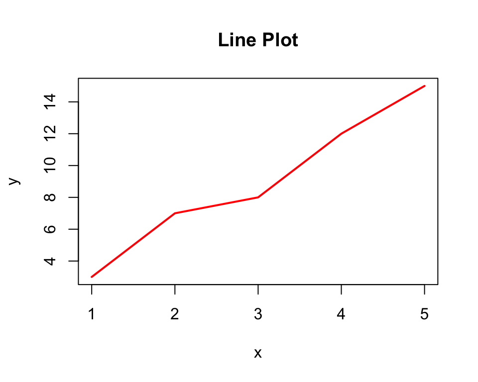

```r
plot(x, y, type = "l", col = "red", lwd = 2, main = "Line Plot")
```

Other common type of plots include bar plot and histogram:

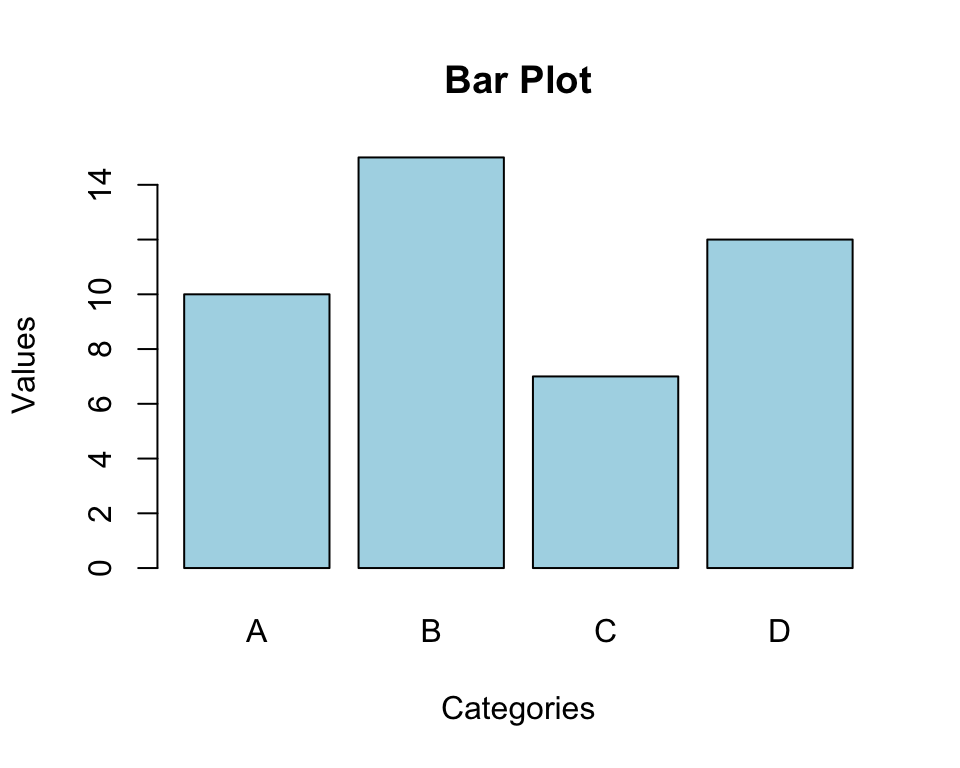

```r
# Sample data
categories <- c("A", "B", "C", "D")
values <- c(10, 15, 7, 12)

# Create a bar plot
barplot(values,
        names.arg = categories,
        col = "lightblue",
        main = "Bar Plot",
        xlab = "Categories",
        ylab = "Values")
```

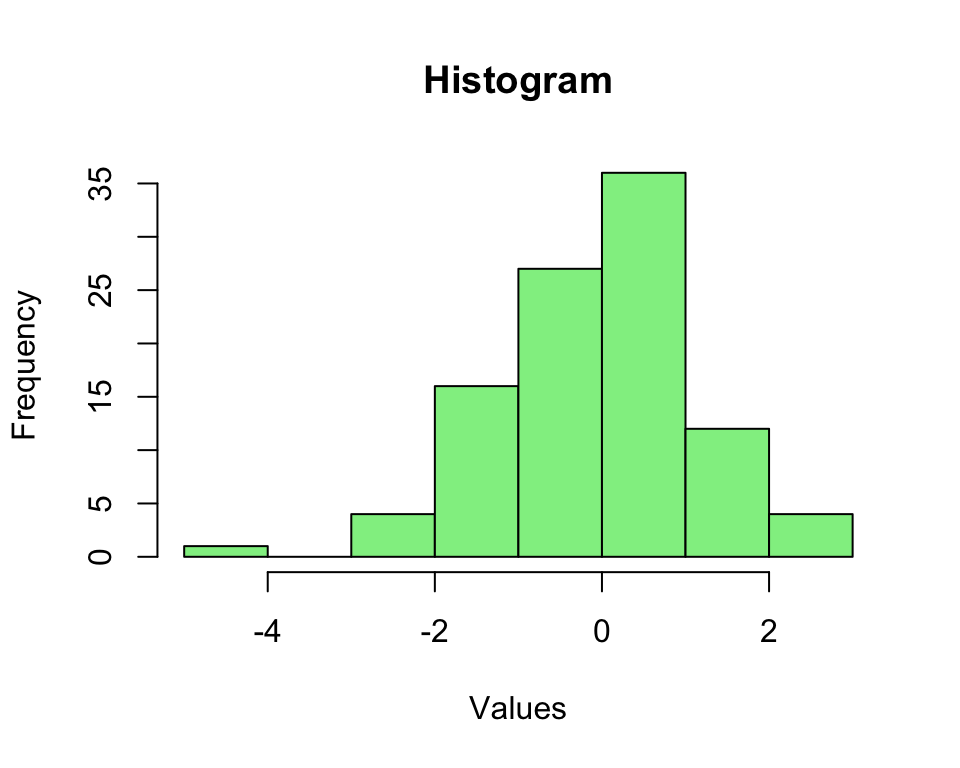

```r
# Generate random data
data <- rnorm(100)

# Create a histogram
hist(data,
     col = "lightgreen",
     main = "Histogram",
     xlab = "Values",
     breaks = 10)
```

The `breaks`-argument in `hist()` defines the number of bins.

##### Advanced plots using **ggplot2**

The `ggplot2` package provides a more advanced and flexible way to create plots using the grammar of graphics approach. To use `ggplot2`, install and load the package first:

```r
install.packages("ggplot2")  # Install package if not already installed; only do once
library(ggplot2)             # Load the package
```

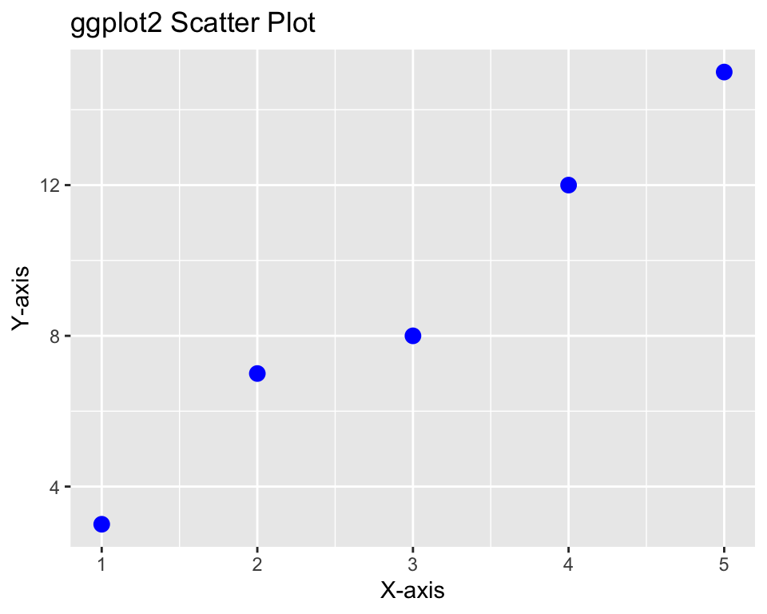

```r
# Sample data
df <- data.frame(x = 1:5, y = c(3, 7, 8, 12, 15))

# Create a scatter plot
ggplot(df, aes(x = x, y = y)) +
  geom_point(color = "blue", size = 3) +
  ggtitle("ggplot2 Scatter Plot") +
  xlab("X-axis") +
  ylab("Y-axis")
```

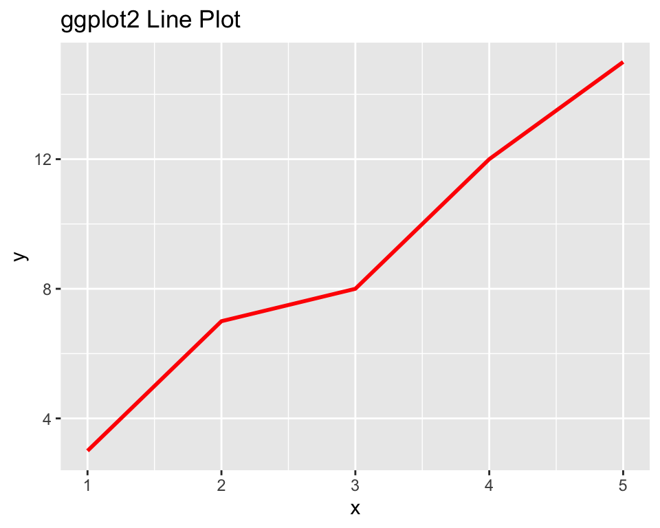

```r
ggplot(df, aes(x = x, y = y)) +
  geom_line(color = "red", size = 1) +
  ggtitle("ggplot2 Line Plot")
```

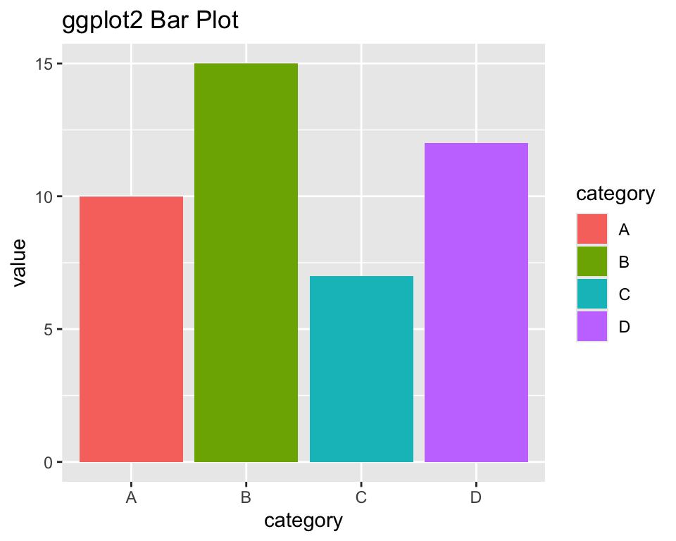

```r
category_data <- data.frame(category = c("A", "B", "C", "D"),
                            value = c(10, 15, 7, 12))

ggplot(category_data, aes(x = category, y = value, fill = category)) +
  geom_bar(stat = "identity") +
  ggtitle("ggplot2 Bar Plot")
```

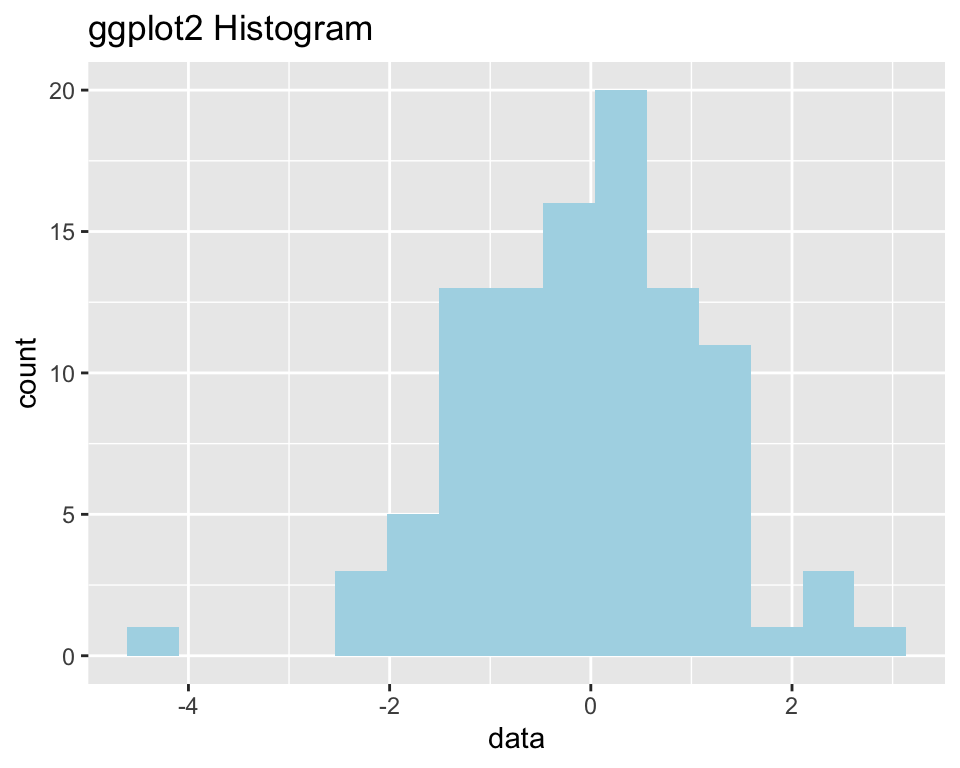

```r
ggplot(data.frame(data), aes(x = data)) +
  geom_histogram(fill = "lightblue", bins = 15) +
  ggtitle("ggplot2 Histogram")
```

Both Base `R` and `ggplot2` allow customizations.

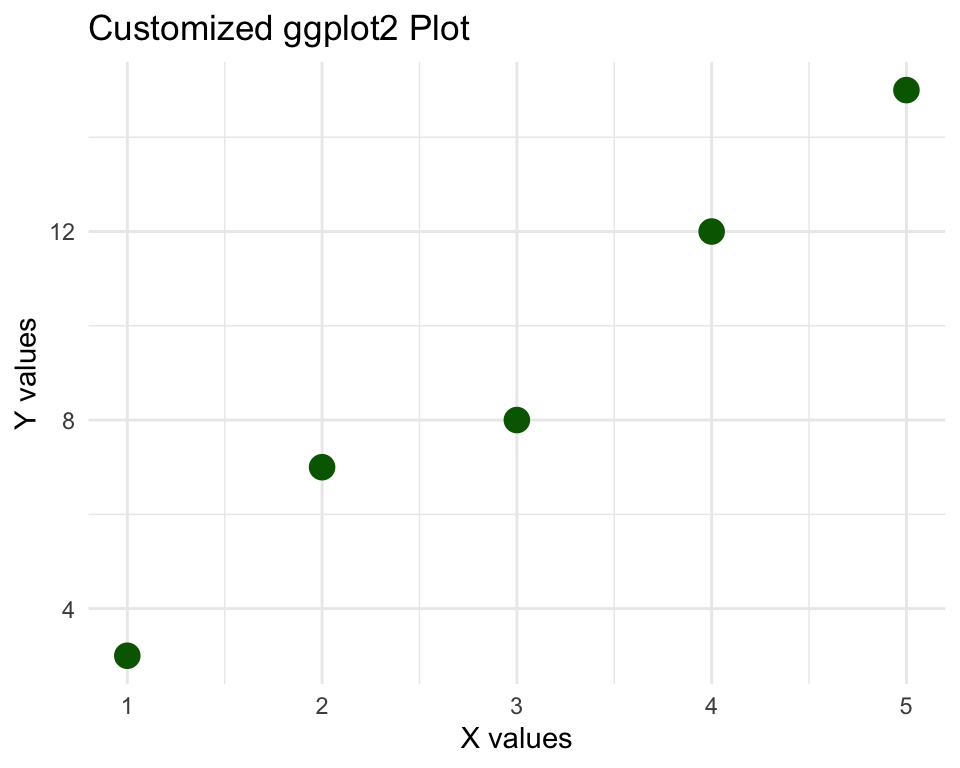

```r
ggplot(df, aes(x, y)) +
  geom_point(color = "darkgreen", size = 4) +
  theme_minimal() +
  labs(title = "Customized ggplot2 Plot", x = "X values", y = "Y values")
```